# Energy Consumption Prediction — Appliances Energy (Wh)

**Goal:** Predict household appliance energy consumption and identify the environmental and behavioural factors that drive it, so that homeowners, building operators and utilities can cut cost, smooth demand peaks and schedule loads more intelligently.

**Dataset:** UCI/Kaggle *Appliances Energy Prediction* — 19,735 records at a regular 10‑minute cadence (Jan–May 2016) with indoor temperature/humidity sensors for 9 zones, outdoor weather‑station data, and the target `Appliances` (Wh).

**Business questions**

1. What drives appliance energy consumption?
2. Can we predict the next interval's energy usage?
3. Which environmental factors matter most?
4. Where are the opportunities to shift load and save cost?

**Approach (honest, leakage‑aware):** this is time‑series data, so we use a **chronological train/test split**, build lag/rolling features with `.shift()` (a row only ever sees the *past*), and model `log1p(Appliances)` to tame the heavy right‑skew — then invert predictions back to Wh for all reported metrics.

```python
import os
import warnings
import numpy as np
import pandas as pd
import matplotlib.pyplot as plt
import seaborn as sns

from sklearn.preprocessing import StandardScaler
from sklearn.linear_model import LinearRegression
from sklearn.ensemble import RandomForestRegressor
from sklearn.model_selection import RandomizedSearchCV, TimeSeriesSplit
from sklearn.metrics import mean_squared_error, mean_absolute_error, r2_score

import xgboost as xgb
import lightgbm as lgb
import optuna
import shap

warnings.filterwarnings("ignore")
optuna.logging.set_verbosity(optuna.logging.WARNING)

RANDOM_STATE = 42
np.random.seed(RANDOM_STATE)

sns.set_theme(style="whitegrid", palette="deep")
plt.rcParams["figure.dpi"] = 110
plt.rcParams["axes.titleweight"] = "bold"

DATA_PATH = "KAG_energydata_complete.csv"
OUT = "outputs"
PLOTS = os.path.join(OUT, "plots")
MODELS = os.path.join(OUT, "models")
EXPORT = os.path.join(OUT, "data")
for d in (PLOTS, MODELS, EXPORT):
    os.makedirs(d, exist_ok=True)


def savefig(name):
    """Save the current figure to outputs/plots; notebook still displays inline."""
    plt.tight_layout()
    plt.savefig(os.path.join(PLOTS, name), bbox_inches="tight")


print("Libraries loaded. Outputs ->", os.path.abspath(OUT))
```

```
Libraries loaded. Outputs -> C:\Working\AI ML Projetcs\Energy consumption Pediction\outputs
```

## 2. Data Understanding

```python
df = pd.read_csv(DATA_PATH)
df["date"] = pd.to_datetime(df["date"])
df = df.sort_values("date").reset_index(drop=True)

print("Shape:", df.shape)
print("Date range:", df["date"].min(), "->", df["date"].max())
cadence = df["date"].diff().dropna().dt.total_seconds().div(60)
print("Sampling cadence (minutes):", cadence.mode().iloc[0],
      "| regular:", cadence.nunique() == 1)
df.head()
```

```
Shape: (19735, 29)
Date range: 2016-01-11 17:00:00 -> 2016-05-27 18:00:00
Sampling cadence (minutes): 10.0 | regular: True
```

|  | date | Appliances | lights | T1 | RH_1 | T2 | RH_2 | T3 | RH_3 | T4 | ... | T9 | RH_9 | T_out | Press_mm_hg | RH_out | Windspeed | Visibility | Tdewpoint | rv1 | rv2 |
| --- | --- | --- | --- | --- | --- | --- | --- | --- | --- | --- | --- | --- | --- | --- | --- | --- | --- | --- | --- | --- | --- |
| 0 | 2016-01-11 17:00:00 | 60 | 30 | 19.89 | 47.596667 | 19.2 | 44.790000 | 19.79 | 44.730000 | 19.000000 | ... | 17.033333 | 45.53 | 6.600000 | 733.5 | 92.0 | 7.000000 | 63.000000 | 5.3 | 13.275433 | 13.275433 |
| 1 | 2016-01-11 17:10:00 | 60 | 30 | 19.89 | 46.693333 | 19.2 | 44.722500 | 19.79 | 44.790000 | 19.000000 | ... | 17.066667 | 45.56 | 6.483333 | 733.6 | 92.0 | 6.666667 | 59.166667 | 5.2 | 18.606195 | 18.606195 |
| 2 | 2016-01-11 17:20:00 | 50 | 30 | 19.89 | 46.300000 | 19.2 | 44.626667 | 19.79 | 44.933333 | 18.926667 | ... | 17.000000 | 45.50 | 6.366667 | 733.7 | 92.0 | 6.333333 | 55.333333 | 5.1 | 28.642668 | 28.642668 |
| 3 | 2016-01-11 17:30:00 | 50 | 40 | 19.89 | 46.066667 | 19.2 | 44.590000 | 19.79 | 45.000000 | 18.890000 | ... | 17.000000 | 45.40 | 6.250000 | 733.8 | 92.0 | 6.000000 | 51.500000 | 5.0 | 45.410389 | 45.410389 |
| 4 | 2016-01-11 17:40:00 | 60 | 40 | 19.89 | 46.333333 | 19.2 | 44.530000 | 19.79 | 45.000000 | 18.890000 | ... | 17.000000 | 45.40 | 6.133333 | 733.9 | 92.0 | 5.666667 | 47.666667 | 4.9 | 10.084097 | 10.084097 |

5 rows × 29 columns

```python
df.describe().T
```

|  | count | mean | min | 25% | 50% | 75% | max | std |
| --- | --- | --- | --- | --- | --- | --- | --- | --- |
| date | 19735 | 2016-03-20 05:29:59.999999 | 2016-01-11 17:00:00 | 2016-02-14 23:15:00 | 2016-03-20 05:30:00 | 2016-04-23 11:45:00 | 2016-05-27 18:00:00 | NaN |
| Appliances | 19735.0 | 97.694958 | 10.0 | 50.0 | 60.0 | 100.0 | 1080.0 | 102.524891 |
| lights | 19735.0 | 3.801875 | 0.0 | 0.0 | 0.0 | 0.0 | 70.0 | 7.935988 |
| T1 | 19735.0 | 21.686571 | 16.79 | 20.76 | 21.6 | 22.6 | 26.26 | 1.606066 |
| RH_1 | 19735.0 | 40.259739 | 27.023333 | 37.333333 | 39.656667 | 43.066667 | 63.36 | 3.979299 |
| T2 | 19735.0 | 20.341219 | 16.1 | 18.79 | 20.0 | 21.5 | 29.856667 | 2.192974 |
| RH_2 | 19735.0 | 40.42042 | 20.463333 | 37.9 | 40.5 | 43.26 | 56.026667 | 4.069813 |
| T3 | 19735.0 | 22.267611 | 17.2 | 20.79 | 22.1 | 23.29 | 29.236 | 2.006111 |
| RH_3 | 19735.0 | 39.2425 | 28.766667 | 36.9 | 38.53 | 41.76 | 50.163333 | 3.254576 |
| T4 | 19735.0 | 20.855335 | 15.1 | 19.53 | 20.666667 | 22.1 | 26.2 | 2.042884 |
| RH_4 | 19735.0 | 39.026904 | 27.66 | 35.53 | 38.4 | 42.156667 | 51.09 | 4.341321 |
| T5 | 19735.0 | 19.592106 | 15.33 | 18.2775 | 19.39 | 20.619643 | 25.795 | 1.844623 |
| RH_5 | 19735.0 | 50.949283 | 29.815 | 45.4 | 49.09 | 53.663333 | 96.321667 | 9.022034 |
| T6 | 19735.0 | 7.910939 | -6.065 | 3.626667 | 7.3 | 11.256 | 28.29 | 6.090347 |
| RH_6 | 19735.0 | 54.609083 | 1.0 | 30.025 | 55.29 | 83.226667 | 99.9 | 31.149806 |
| T7 | 19735.0 | 20.267106 | 15.39 | 18.7 | 20.033333 | 21.6 | 26.0 | 2.109993 |
| RH_7 | 19735.0 | 35.3882 | 23.2 | 31.5 | 34.863333 | 39.0 | 51.4 | 5.114208 |
| T8 | 19735.0 | 22.029107 | 16.306667 | 20.79 | 22.1 | 23.39 | 27.23 | 1.956162 |
| RH_8 | 19735.0 | 42.936165 | 29.6 | 39.066667 | 42.375 | 46.536 | 58.78 | 5.224361 |
| T9 | 19735.0 | 19.485828 | 14.89 | 18.0 | 19.39 | 20.6 | 24.5 | 2.014712 |
| RH_9 | 19735.0 | 41.552401 | 29.166667 | 38.5 | 40.9 | 44.338095 | 53.326667 | 4.151497 |
| T_out | 19735.0 | 7.411665 | -5.0 | 3.666667 | 6.916667 | 10.408333 | 26.1 | 5.317409 |
| Press_mm_hg | 19735.0 | 755.522602 | 729.3 | 750.933333 | 756.1 | 760.933333 | 772.3 | 7.399441 |
| RH_out | 19735.0 | 79.750418 | 24.0 | 70.333333 | 83.666667 | 91.666667 | 100.0 | 14.901088 |
| Windspeed | 19735.0 | 4.039752 | 0.0 | 2.0 | 3.666667 | 5.5 | 14.0 | 2.451221 |
| Visibility | 19735.0 | 38.330834 | 1.0 | 29.0 | 40.0 | 40.0 | 66.0 | 11.794719 |
| Tdewpoint | 19735.0 | 3.760707 | -6.6 | 0.9 | 3.433333 | 6.566667 | 15.5 | 4.194648 |
| rv1 | 19735.0 | 24.988033 | 0.005322 | 12.497889 | 24.897653 | 37.583769 | 49.99653 | 14.496634 |
| rv2 | 19735.0 | 24.988033 | 0.005322 | 12.497889 | 24.897653 | 37.583769 | 49.99653 | 14.496634 |

### Missing values & data quality

```python
print("Total missing values:", int(df.isnull().sum().sum()))
print("rv1 and rv2 identical:", np.allclose(df["rv1"], df["rv2"]))
print("corr(rv1, Appliances):", round(df["rv1"].corr(df["Appliances"]), 4))
print("\nTarget (Appliances, Wh) summary:")
print(df["Appliances"].describe().round(2).to_string())
print("Skewness:", round(df["Appliances"].skew(), 3))
```

```
Total missing values: 0
rv1 and rv2 identical: True
corr(rv1, Appliances): -0.0111

Target (Appliances, Wh) summary:
count    19735.00
mean        97.69
std        102.52
min         10.00
25%         50.00
50%         60.00
75%        100.00
max       1080.00
Skewness: 3.386
```

```python
# Time-based features are created up front because the EDA uses them.
df["hour"] = df["date"].dt.hour
df["dayofweek"] = df["date"].dt.dayofweek          # 0 = Monday
df["day"] = df["date"].dt.day
df["month"] = df["date"].dt.month
df["is_weekend"] = (df["dayofweek"] >= 5).astype(int)
df["is_night"] = df["hour"].apply(lambda h: 1 if (h >= 22 or h < 6) else 0)
df["dayname"] = df["date"].dt.day_name()
```

## 3. Exploratory Data Analysis (EDA)

### Plot 1 — Energy consumption distribution

Purpose: detect skew and outliers. Expectation: heavily right‑skewed with a long tail of high‑consumption bursts. The `log1p` view (right) is far more symmetric — this is exactly why we model the log of the target.

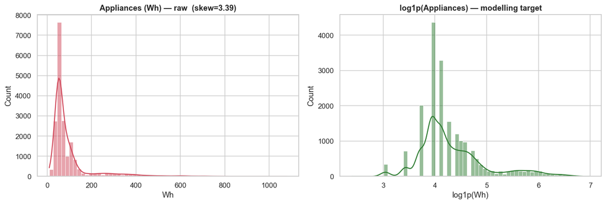

```python
fig, ax = plt.subplots(1, 2, figsize=(13, 4.5))
sns.histplot(df["Appliances"], bins=60, kde=True, color="#d1495b", ax=ax[0])
ax[0].set_title(f"Appliances (Wh) — raw  (skew={df['Appliances'].skew():.2f})")
ax[0].set_xlabel("Wh")
sns.histplot(np.log1p(df["Appliances"]), bins=60, kde=True, color="#2e7d32", ax=ax[1])
ax[1].set_title("log1p(Appliances) — modelling target")
ax[1].set_xlabel("log1p(Wh)")
savefig("01_target_distribution.png")
```

### Plot 2 — Hour of day vs energy

Purpose: find peak‑usage windows for load‑shifting. Expectation: a mid‑morning rise and a pronounced evening peak; lowest usage overnight.

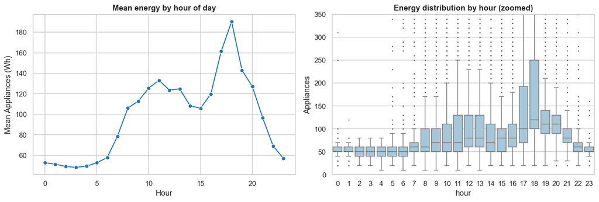

```python
fig, ax = plt.subplots(1, 2, figsize=(13, 4.5))
hourly = df.groupby("hour")["Appliances"].mean()
sns.lineplot(x=hourly.index, y=hourly.values, marker="o", color="#1f77b4", ax=ax[0])
ax[0].set_title("Mean energy by hour of day")
ax[0].set_xlabel("Hour"); ax[0].set_ylabel("Mean Appliances (Wh)")
sns.boxplot(data=df, x="hour", y="Appliances", color="#9ecae1", fliersize=1, ax=ax[1])
ax[1].set_ylim(0, 350)
ax[1].set_title("Energy distribution by hour (zoomed)")
savefig("02_hour_vs_energy.png")
```

### Plot 3 — Temperature vs energy (HVAC dependency)

Purpose: test heating/cooling dependency. We bin outdoor temperature and plot mean energy per bin to cut through the 19k‑point scatter.

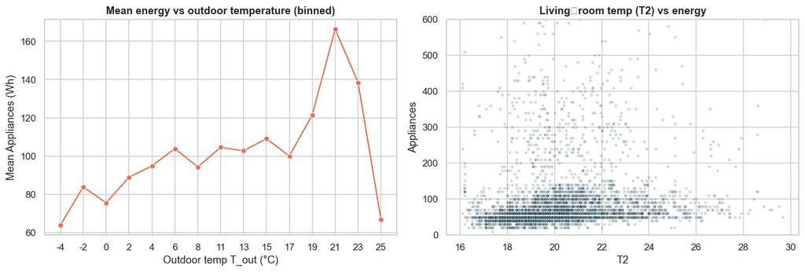

```python
fig, ax = plt.subplots(1, 2, figsize=(13, 4.5))
df["_Tout_bin"] = pd.cut(df["T_out"], bins=15)
tbin = df.groupby("_Tout_bin", observed=True)["Appliances"].mean()
xlabels = [f"{i.mid:.0f}" for i in tbin.index]
sns.lineplot(x=range(len(tbin)), y=tbin.values, marker="o", color="#e76f51", ax=ax[0])
ax[0].set_xticks(range(len(tbin))); ax[0].set_xticklabels(xlabels, rotation=0)
ax[0].set_title("Mean energy vs outdoor temperature (binned)")
ax[0].set_xlabel("Outdoor temp T_out (°C)"); ax[0].set_ylabel("Mean Appliances (Wh)")
samp = df.sample(4000, random_state=RANDOM_STATE)
sns.scatterplot(data=samp, x="T2", y="Appliances", alpha=0.2, s=12, color="#264653", ax=ax[1])
ax[1].set_ylim(0, 600)
ax[1].set_title("Living‑room temp (T2) vs energy")
df.drop(columns="_Tout_bin", inplace=True)
savefig("03_temperature_vs_energy.png")
```

### Plot 4 — Humidity vs energy

Purpose: gauge the humidity/HVAC link. Expectation: a mild positive relation.

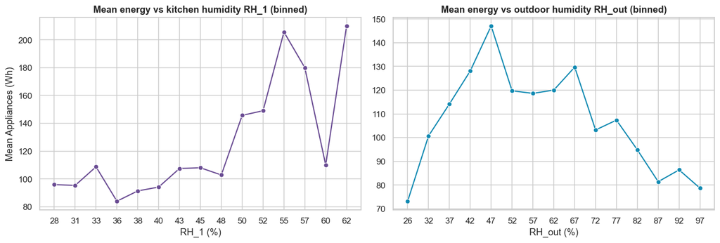

```python
fig, ax = plt.subplots(1, 2, figsize=(13, 4.5))
df["_RH1_bin"] = pd.cut(df["RH_1"], bins=15)
hbin = df.groupby("_RH1_bin", observed=True)["Appliances"].mean()
hx = [f"{i.mid:.0f}" for i in hbin.index]
sns.lineplot(x=range(len(hbin)), y=hbin.values, marker="o", color="#6a4c93", ax=ax[0])
ax[0].set_xticks(range(len(hbin))); ax[0].set_xticklabels(hx)
ax[0].set_title("Mean energy vs kitchen humidity RH_1 (binned)")
ax[0].set_xlabel("RH_1 (%)"); ax[0].set_ylabel("Mean Appliances (Wh)")
df["_RHout_bin"] = pd.cut(df["RH_out"], bins=15)
hbin2 = df.groupby("_RHout_bin", observed=True)["Appliances"].mean()
hx2 = [f"{i.mid:.0f}" for i in hbin2.index]
sns.lineplot(x=range(len(hbin2)), y=hbin2.values, marker="o", color="#118ab2", ax=ax[1])
ax[1].set_xticks(range(len(hbin2))); ax[1].set_xticklabels(hx2)
ax[1].set_title("Mean energy vs outdoor humidity RH_out (binned)")
ax[1].set_xlabel("RH_out (%)")
df.drop(columns=["_RH1_bin", "_RHout_bin"], inplace=True)
savefig("04_humidity_vs_energy.png")
```

### Plot 5 — Correlation heatmap & strongest linear drivers

Purpose: find the strongest linear relationships with the target. With ~28 numeric columns the full heatmap shows structure (room temperatures move together); the sorted bar chart ranks each feature's correlation with energy.

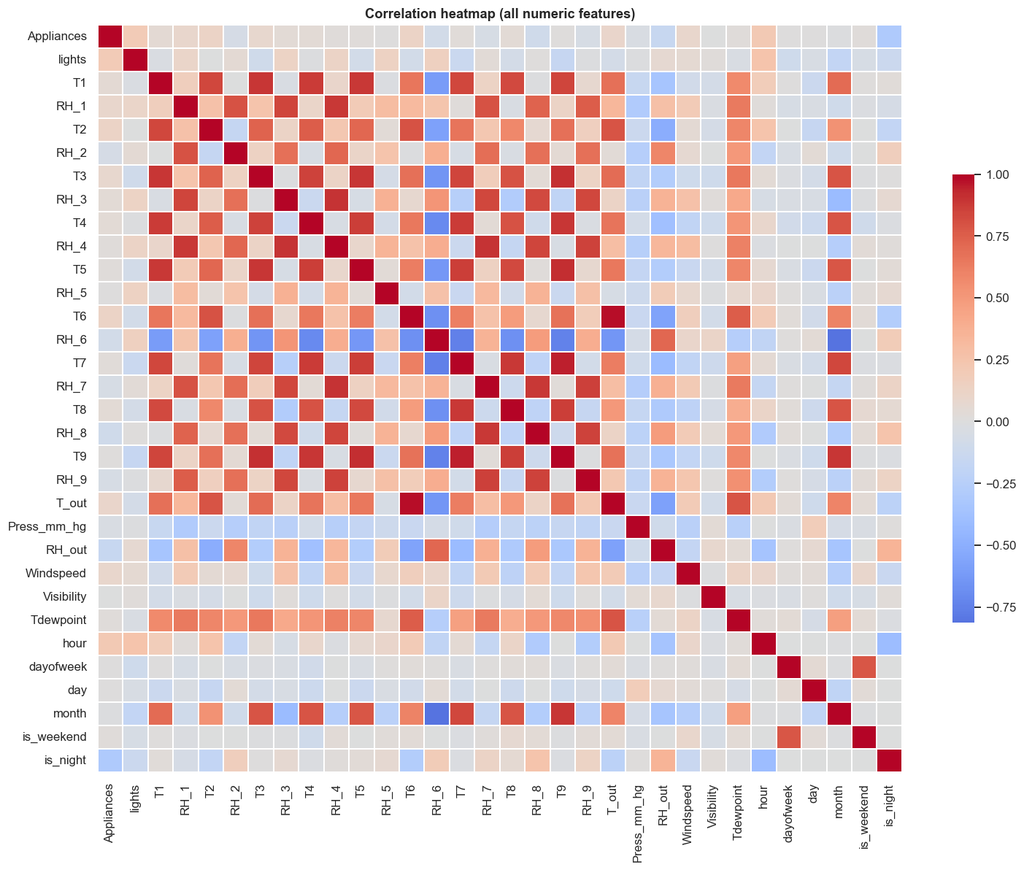

```python
num = df.select_dtypes(include=[np.number]).drop(columns=["rv1", "rv2"], errors="ignore")
corr = num.corr()

fig, ax = plt.subplots(figsize=(14, 11))
sns.heatmap(corr, cmap="coolwarm", center=0, linewidths=.3, square=False,
            cbar_kws={"shrink": .6}, ax=ax)
ax.set_title("Correlation heatmap (all numeric features)")
savefig("05a_correlation_heatmap.png")
```

```
Top positive drivers:
 Windspeed    0.087
T_out        0.099
T6           0.118
T2           0.120
lights       0.197
hour         0.217
```

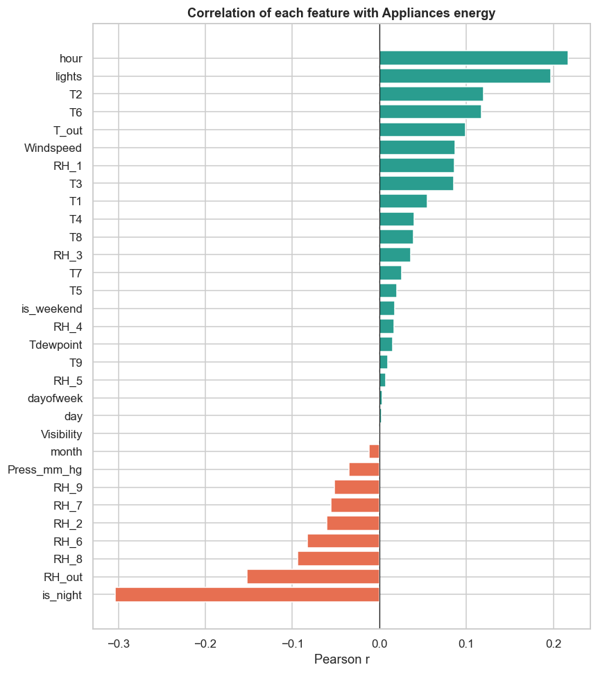

```python
target_corr = corr["Appliances"].drop("Appliances").sort_values()
fig, ax = plt.subplots(figsize=(8, 9))
colors = ["#2a9d8f" if v > 0 else "#e76f51" for v in target_corr.values]
ax.barh(target_corr.index, target_corr.values, color=colors)
ax.set_title("Correlation of each feature with Appliances energy")
ax.set_xlabel("Pearson r")
ax.axvline(0, color="k", lw=.8)
savefig("05b_target_correlations.png")
print("Top positive drivers:\n", target_corr.tail(6).round(3).to_string())
```

### Plot 6 — Temporal trend & weekly seasonality

Purpose: expose recurring daily/weekly patterns that justify time features. The daily series shows the overall trajectory; the hour × weekday heatmap reveals *when* the household is energy‑hungry (weekday evenings).

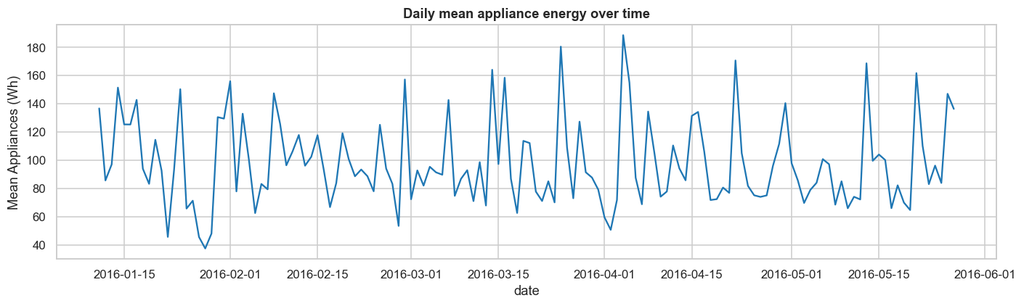

```python
daily = df.set_index("date")["Appliances"].resample("D").mean()
fig, ax = plt.subplots(figsize=(13, 4))
sns.lineplot(x=daily.index, y=daily.values, color="#1f77b4", ax=ax)
ax.set_title("Daily mean appliance energy over time")
ax.set_ylabel("Mean Appliances (Wh)")
savefig("06a_daily_trend.png")
```

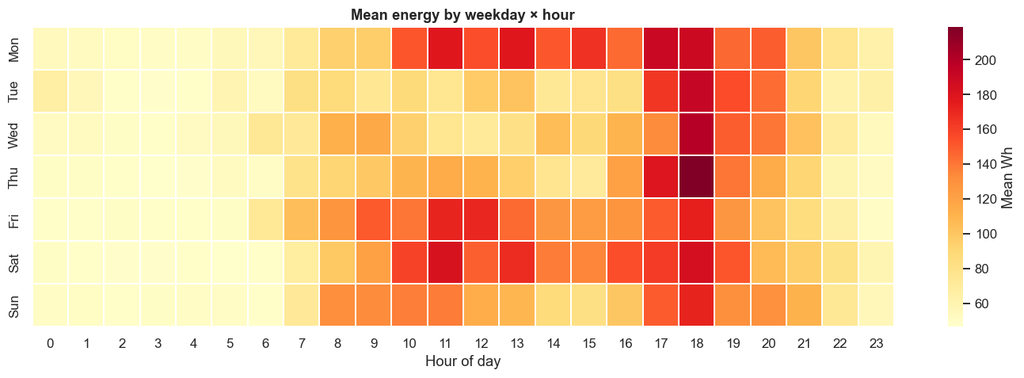

```python
pivot = (df.groupby(["dayofweek", "hour"])["Appliances"].mean()
           .unstack(level="hour"))
pivot.index = ["Mon", "Tue", "Wed", "Thu", "Fri", "Sat", "Sun"]
fig, ax = plt.subplots(figsize=(13, 4.5))
sns.heatmap(pivot, cmap="YlOrRd", linewidths=.3, cbar_kws={"label": "Mean Wh"}, ax=ax)
ax.set_title("Mean energy by weekday × hour")
ax.set_xlabel("Hour of day"); ax.set_ylabel("")
savefig("06b_weekday_hour_heatmap.png")
```

## 4. Data Cleaning & Outlier Treatment

No missing values to impute. For outliers we *quantify* the IQR‑defined extremes but deliberately **do not delete them**: those high‑consumption bursts are precisely the demand‑peak events the business wants to predict. Modelling `log1p(Appliances)` already compresses the tail, giving us the benefit of winsorization without discarding the events that matter.

```python
q1, q3 = df["Appliances"].quantile([.25, .75])
iqr = q3 - q1
upper = q3 + 1.5 * iqr
n_out = int((df["Appliances"] > upper).sum())
print(f"IQR upper fence: {upper:.0f} Wh")
print(f"Intervals above fence: {n_out} ({100*n_out/len(df):.1f}%) — kept as genuine demand peaks")
```

```
IQR upper fence: 175 Wh
Intervals above fence: 2138 (10.8%) — kept as genuine demand peaks
```

## 5. Feature Engineering

| Feature | Rationale |
| --- | --- |
| `hour`, `is_weekend`, `is_night`, `month` | capture daily/weekly behaviour |
| `hour_sin`, `hour_cos` | cyclical encoding so 23h and 0h are adjacent |
| `indoor_temp_mean` | overall house warmth (rooms move together) |
| `temp_diff` = indoor − outdoor | the key HVAC heating/cooling driver |
| `lag_1/2/3` | energy is strongly autocorrelated (recent past predicts next step) |
| `roll_mean_3/6/18`, `roll_std_6` | short/medium‑term consumption trend & volatility (last 30 min → 3 h) |

All lag/rolling features use `.shift(1)` so a row only sees **past** values — this is what makes the chronological evaluation leakage‑free.

```python
indoor_cols = ["T1", "T2", "T3", "T4", "T5", "T7", "T8", "T9"]  # T6 is outdoors
df["indoor_temp_mean"] = df[indoor_cols].mean(axis=1)
df["temp_diff"] = df["indoor_temp_mean"] - df["T_out"]
df["hour_sin"] = np.sin(2 * np.pi * df["hour"] / 24)
df["hour_cos"] = np.cos(2 * np.pi * df["hour"] / 24)

for k in (1, 2, 3):
    df[f"lag_{k}"] = df["Appliances"].shift(k)
df["roll_mean_3"] = df["Appliances"].shift(1).rolling(3).mean()     # ~30 min
df["roll_mean_6"] = df["Appliances"].shift(1).rolling(6).mean()     # ~1 h
df["roll_mean_18"] = df["Appliances"].shift(1).rolling(18).mean()   # ~3 h
df["roll_std_6"] = df["Appliances"].shift(1).rolling(6).std()

before = len(df)
df = df.dropna().reset_index(drop=True)
print(f"Dropped {before - len(df)} warm-up rows with NaN lags. Rows remaining: {len(df)}")
```

```
Dropped 18 warm-up rows with NaN lags. Rows remaining: 19717
```

## 6. Modelling Setup — chronological split & log target

```python
drop_cols = ["date", "Appliances", "rv1", "rv2", "dayname"]
feature_cols = [c for c in df.columns if c not in drop_cols]

X = df[feature_cols].copy()
y = np.log1p(df["Appliances"].values)          # model log target
y_true_wh = df["Appliances"].values            # for reference

# Chronological 80/20 split (no shuffling — respect time order)
split = int(len(df) * 0.8)
X_train, X_test = X.iloc[:split], X.iloc[split:]
y_train, y_test = y[:split], y[split:]
print(f"Train: {X_train.shape}  Test: {X_test.shape}")
print(f"Train period ends, test period begins at: {df['date'].iloc[split]}")

# Scaled copies for the linear baseline (trees don't need scaling)
scaler = StandardScaler().fit(X_train)
X_train_s = scaler.transform(X_train)
X_test_s = scaler.transform(X_test)

tscv = TimeSeriesSplit(n_splits=3)
results = {}
models = {}


def evaluate(name, model, Xte, store=True):
    """Predict on (log) scale, invert to Wh, score on the real scale."""
    pred_log = model.predict(Xte)
    yp = np.clip(np.expm1(pred_log), 0, None)
    yt = np.expm1(y_test)
    rmse = float(np.sqrt(mean_squared_error(yt, yp)))
    mae = float(mean_absolute_error(yt, yp))
    r2 = float(r2_score(yt, yp))
    if store:
        results[name] = {"RMSE (Wh)": rmse, "MAE (Wh)": mae, "R2": r2}
        models[name] = model
    print(f"{name:<22} R2={r2:6.3f}   RMSE={rmse:6.1f} Wh   MAE={mae:6.1f} Wh")
    return yp
```

```
Train: (15773, 42)  Test: (3944, 42)
Train period ends, test period begins at: 2016-04-30 08:50:00
```

### Baseline — Linear Regression

Fast, fully interpretable, but cannot model the non‑linear HVAC/time effects.

```python
lr = LinearRegression().fit(X_train_s, y_train)
evaluate("Linear Regression", lr, X_test_s)
```

```
Linear Regression      R2= 0.401   RMSE=  70.1 Wh   MAE=  28.1 Wh
```

```
array([165.3408347 , 205.18698813, 164.39092424, ...,  95.33053655,
       191.42861739, 314.15529626], shape=(3944,))
```

### Model 1 — Random Forest (with randomized tuning)

Captures non‑linear temperature/time/weather interactions. Tuned with `RandomizedSearchCV` over a `TimeSeriesSplit` so validation always trains on the past and tests on the future.

```python
rf_dist = {
    "n_estimators": [200, 300, 400],
    "max_depth": [10, 15, 20, None],
    "min_samples_split": [2, 5, 10],
    "min_samples_leaf": [1, 2, 4],
    "max_features": ["sqrt", 0.5],
}
rf_search = RandomizedSearchCV(
    RandomForestRegressor(random_state=RANDOM_STATE, n_jobs=-1),
    rf_dist, n_iter=8, cv=tscv, scoring="r2",
    random_state=RANDOM_STATE, n_jobs=-1, verbose=0,
)
rf_search.fit(X_train, y_train)
print("Best RF params:", rf_search.best_params_)
evaluate("Random Forest", rf_search.best_estimator_, X_test)
```

```
Best RF params: {'n_estimators': 200, 'min_samples_split': 10, 'min_samples_leaf': 4, 'max_features': 0.5, 'max_depth': None}
Random Forest          R2= 0.558   RMSE=  60.2 Wh   MAE=  27.9 Wh
```

```
array([243.40849199, 240.08911281, 215.44036932, ..., 129.34798861,
       333.19154834, 227.23795672], shape=(3944,))
```

### Model 2 — XGBoost (with randomized tuning)

```python
xgb_dist = {
    "n_estimators": [300, 500, 700],
    "max_depth": [3, 5, 7, 9],
    "learning_rate": [0.03, 0.05, 0.1],
    "subsample": [0.7, 0.85, 1.0],
    "colsample_bytree": [0.7, 0.85, 1.0],
    "gamma": [0, 1, 5],
}
xgb_search = RandomizedSearchCV(
    xgb.XGBRegressor(random_state=RANDOM_STATE, n_jobs=-1,
                     tree_method="hist", verbosity=0),
    xgb_dist, n_iter=12, cv=tscv, scoring="r2",
    random_state=RANDOM_STATE, n_jobs=-1, verbose=0,
)
xgb_search.fit(X_train, y_train)
print("Best XGB params:", xgb_search.best_params_)
evaluate("XGBoost", xgb_search.best_estimator_, X_test)
```

```
Best XGB params: {'subsample': 0.85, 'n_estimators': 500, 'max_depth': 9, 'learning_rate': 0.1, 'gamma': 5, 'colsample_bytree': 1.0}
XGBoost                R2= 0.560   RMSE=  60.1 Wh   MAE=  23.6 Wh
```

```
array([227.57465, 227.57465, 189.20078, ...,  98.9014 , 278.70572,
       223.09654], shape=(3944,), dtype=float32)
```

### Model 3 — LightGBM (tuned with Optuna)

Fast histogram‑based gradient boosting; Optuna searches the space efficiently using the same time‑series CV objective (mean R² on the log target).

```python
def lgb_objective(trial):
    params = {
        "n_estimators": trial.suggest_int("n_estimators", 300, 900, step=100),
        "num_leaves": trial.suggest_int("num_leaves", 20, 120),
        "max_depth": trial.suggest_int("max_depth", 3, 12),
        "learning_rate": trial.suggest_float("learning_rate", 0.01, 0.15, log=True),
        "feature_fraction": trial.suggest_float("feature_fraction", 0.6, 1.0),
        "bagging_fraction": trial.suggest_float("bagging_fraction", 0.6, 1.0),
        "min_data_in_leaf": trial.suggest_int("min_data_in_leaf", 10, 60),
    }
    scores = []
    for tr_idx, va_idx in tscv.split(X_train):
        m = lgb.LGBMRegressor(random_state=RANDOM_STATE, n_jobs=-1,
                              verbose=-1, **params)
        m.fit(X_train.iloc[tr_idx], y_train[tr_idx])
        scores.append(r2_score(y_train[va_idx], m.predict(X_train.iloc[va_idx])))
    return float(np.mean(scores))


study = optuna.create_study(direction="maximize",
                            sampler=optuna.samplers.TPESampler(seed=RANDOM_STATE))
study.optimize(lgb_objective, n_trials=25, show_progress_bar=False)
print("Best LGBM params:", study.best_params)

best_lgb = lgb.LGBMRegressor(random_state=RANDOM_STATE, n_jobs=-1,
                             verbose=-1, **study.best_params)
best_lgb.fit(X_train, y_train)
evaluate("LightGBM", best_lgb, X_test)
```

```
Best LGBM params: {'n_estimators': 400, 'num_leaves': 91, 'max_depth': 5, 'learning_rate': 0.010410730772074085, 'feature_fraction': 0.6124424416624404, 'bagging_fraction': 0.870140098592377, 'min_data_in_leaf': 43}
```

```
LightGBM               R2= 0.572   RMSE=  59.3 Wh   MAE=  23.7 Wh
```

```
array([230.61640388, 230.19385284, 203.6283638 , ..., 109.664843  ,
       341.14401709, 211.20691577], shape=(3944,))
```

## Model Comparison

```python
comparison = (pd.DataFrame(results).T
              .sort_values("R2", ascending=False)
              .round({"RMSE (Wh)": 1, "MAE (Wh)": 1, "R2": 3}))
print(comparison.to_string())
best_name = comparison.index[0]
best_model = models[best_name]
print("\nBest model:", best_name)
```

```
                   RMSE (Wh)  MAE (Wh)     R2
LightGBM                59.3      23.7  0.572
XGBoost                 60.1      23.6  0.560
Random Forest           60.2      27.9  0.558
Linear Regression       70.1      28.1  0.401

Best model: LightGBM
```

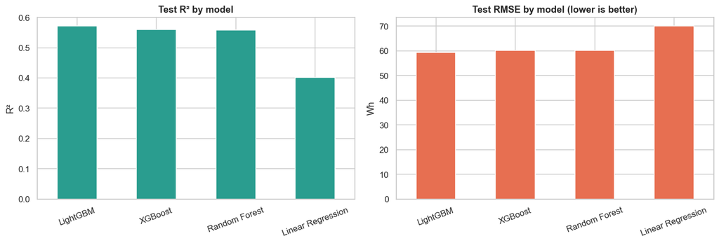

```python
fig, ax = plt.subplots(1, 2, figsize=(13, 4.5))
comparison["R2"].plot(kind="bar", color="#2a9d8f", ax=ax[0])
ax[0].set_title("Test R² by model"); ax[0].set_ylabel("R²")
ax[0].tick_params(axis="x", rotation=20)
comparison["RMSE (Wh)"].plot(kind="bar", color="#e76f51", ax=ax[1])
ax[1].set_title("Test RMSE by model (lower is better)"); ax[1].set_ylabel("Wh")
ax[1].tick_params(axis="x", rotation=20)
savefig("07_model_comparison.png")
```

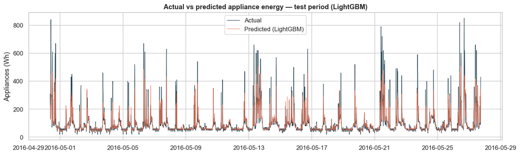

```python
# Actual vs predicted over the (held-out future) test period for the best model.
best_pred = np.clip(np.expm1(best_model.predict(
    X_test if best_name != "Linear Regression" else X_test_s)), 0, None)
test_dates = df["date"].iloc[split:]
fig, ax = plt.subplots(figsize=(13, 4))
ax.plot(test_dates.values, np.expm1(y_test), label="Actual", color="#264653", lw=.8)
ax.plot(test_dates.values, best_pred, label=f"Predicted ({best_name})",
        color="#e76f51", lw=.8, alpha=.8)
ax.set_title(f"Actual vs predicted appliance energy — test period ({best_name})")
ax.set_ylabel("Appliances (Wh)"); ax.legend()
savefig("08_actual_vs_predicted.png")
```

## Explainability — SHAP

SHAP decomposes each prediction into per‑feature contributions, answering *which variables matter most* and *why a given prediction is high or low*. We explain the best tree model on a sample of the held‑out test set.

```
Top 10 drivers by mean |SHAP|:
 lag_1          0.2206
roll_mean_3    0.1008
roll_mean_6    0.0302
lag_2          0.0281
hour_cos       0.0233
hour_sin       0.0148
is_night       0.0119
lag_3          0.0118
roll_std_6     0.0110
lights         0.0104
```

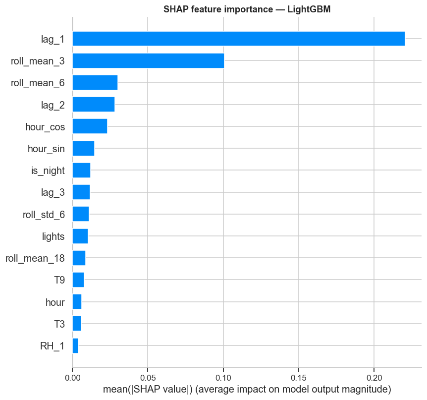

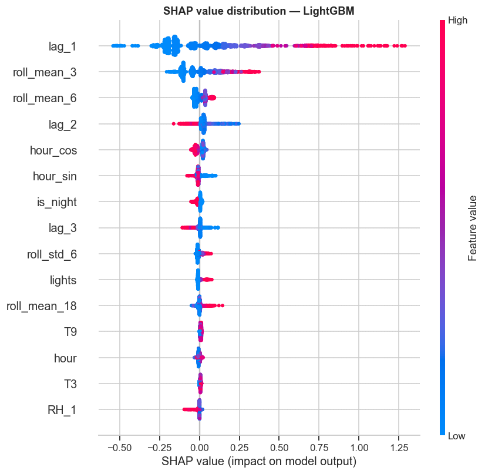

```python
shap_model = best_model if best_name != "Linear Regression" else best_lgb
shap_label = best_name if best_name != "Linear Regression" else "LightGBM"
X_shap = X_test.sample(min(2000, len(X_test)), random_state=RANDOM_STATE)
explainer = shap.TreeExplainer(shap_model)
shap_values = explainer.shap_values(X_shap)

plt.figure()
shap.summary_plot(shap_values, X_shap, plot_type="bar", show=False, max_display=15)
plt.title(f"SHAP feature importance — {shap_label}")
savefig("09a_shap_importance.png")

plt.figure()
shap.summary_plot(shap_values, X_shap, show=False, max_display=15)
plt.title(f"SHAP value distribution — {shap_label}")
savefig("09b_shap_beeswarm.png")

mean_abs = pd.Series(np.abs(shap_values).mean(axis=0),
                     index=X_shap.columns).sort_values(ascending=False)
print("Top 10 drivers by mean |SHAP|:\n", mean_abs.head(10).round(4).to_string())
```